# Fuzzy Spectral Clustering with Variable-Weighted Adjacency Matrices

Jesse S. Ghashti and John R. J. Thompson

2025-10-04

# Introduction

The **FuzzySpec** package implements the **FVIBES** (Fuzzy Variable-Importance Based Eigenspace Separation) algorithm, a fuzzy spectral clustering procedure that incorporates variable-weighted distance metrics and adaptive adjacency matrix constructions. This package accompanies the paper *Variable-Weighted Adjacency Constructions for Fuzzy Spectral Clustering* by Ghashti, Hare, and Thompson (2025).

The key features of this package include:

- a variable-weighted distance metric that automatically determines variable importance using nonparametric kernel density estimation,
- an adaptive adjacency construction framework with multiple options for building similarity graphs including locally-adaptive scaling (Zelnik-Manor and Perona, 2004),
- clustering outputs that return fuzzy membership matrices rather than just hard cluster assignments, and
- a synthetic dataset generation containing built-in generators to benchmark fuzzy clustering algorithms.

## Package Overview

There are three primary functions needed to conduct FVIBES clustering:

1. Build an adjacency matrix from the data using `make.adjacency()`
2. Perform fuzzy spectral clustering using `fuzzy.spectral.clustering()`
3. Optionally, examine results results with 2D visualization function `plot.fuzzy()` or compare to true class labels using `clustering.accuracy()`.

# Installation

Install the latest release version of **FuzzySpec** from [GitHub](https://github.com/ghashti-j/FuzzySpec) or with the following:

```r
library(devtools)
install_github("ghashti-j/FuzzySpec")
library(FuzzySpec)
```

# Sample Usage

The basic steps using built-in function are provided below.

1. First we generate a synthetic dataset `spirals`, see the help file for `gen.fuzzy()` for more options and information.

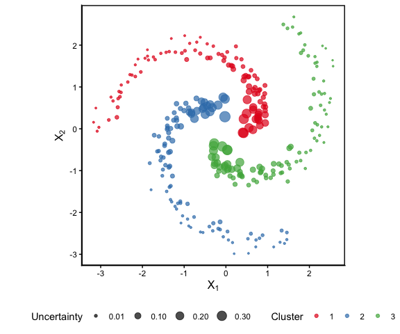

```r
set.seed(1)
data <- FuzzySpec::gen.fuzzy(n = 300, dataset = "spirals", noise = 0.15) # data generation
FuzzySpec::plot.fuzzy(data, plotFuzzy = TRUE, colorCluster = TRUE) # plot data generating process
```

2. Build a variable-weighted locally-adaptive adjacency matrix, corresponding to the adjacency $\mathbf{W}^{(\text{vwla-id})}$ in Ghashti et al. (2025):

```r
W <- FuzzySpec::make.adjacency(
  data = data$X,
  method = "vw",           # variable-weighted distances
  isLocWeighted = TRUE,    # Locally-adaptive scaling
  scale = FALSE            # scaling not required for kernel methods
)
```

[output not shown]

3. Perform fuzzy spectral clustering given the adjacency matrix $\mathbf{W}$, number of clusters `k = 3` and the commonly chosen fuzzy parameter `m = 1.5`. We display the first 5 rows of the membership matrix $\mathbf{U}$:

```r
res <- FuzzySpec::fuzzy.spectral.clustering(
  W = W, k = 3, m = 1.5, method = "CM"
)
res$u[1:5,]
```

```
#>          Clus 1     Clus 2     Clus 3
#> Obj 1 0.9048457 0.05660900 0.03854527
#> Obj 2 0.9549308 0.02402001 0.02104920
#> Obj 3 0.9092418 0.05372531 0.03703293
#> Obj 4 0.9764813 0.01192352 0.01159519
#> Obj 5 0.9590105 0.02179147 0.01919800
```

4. We can compare the hard clustering results to the true class labels:

```r
acc <- FuzzySpec::clustering.accuracy(data$y, res$cluster)
cat("Clustering accuracy:", round(acc, 3), "\n")
```

```
#> Clustering accuracy: 0.99
```

5. We can compare the membership matrix $\mathbf{U}$ determined by FVIBES to the true probabilistic cluster memberships with function `fari`, which computes fuzzy generalizations of the Adjusted Rand Index (FARI) based on Frobenius inner products of membership matrices (Andrews, Brown and Hvingelby, 2022).

```r
far <- FuzzySpec::fari(data$U, res$u)
cat("FARI:", round(far, 3), "\n")
```

```
#> FARI: 0.98
```

6. Finally, we can visualize the clustering results with observations, where observations are assigned by hard cluster labels and sized by the membership matrix $\mathbf{U}$:

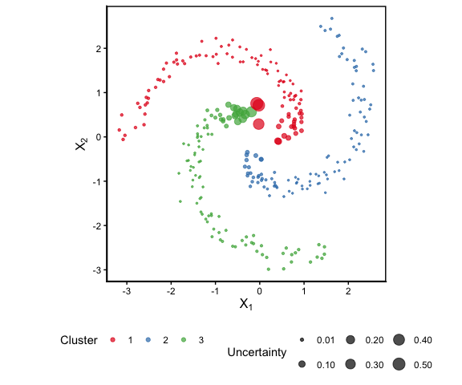

```r
resDF <- list(
  X = data$X, U = res$u, y = factor(res$cluster), k = 3
)
FuzzySpec::plot.fuzzy(resDF, plotFuzzy = TRUE, colorCluster = TRUE)
```

## Adjacency Construction

See respective help files for each function when needed; here we provide a basic overview of function arguments for `make.adjacency()`. This function allows for flexible adjacency matrix constructions based on Ghashti et al. (2025). The parameters are as follows:

- `method`: distance metric
  - `"eu"`: squared Euclidean distance
  - `"vw"`: variable-weighted distance using kernel density bandwidth estimation
- `isLocWeighted`: scaling approach
  - `TRUE`: locally-adaptive scaling (Zelnik-Manor & Perona, 2004)
  - `FALSE`: global scaling with parameter `sig`
- `isModWeighted`: apply similarity weightings
  - `ModMethod = "snn"`: shared nearest neighbors (Jarvis & Patrick, 1973)
  - `ModMethod = "sim"`: similarity-based weighting
  - `ModMethod = "both"`: combined SNN and SIM
- `isSparse`: returns a sparse matrix when using weightings

**References**

- Andrews, J.L., Browne, R. and C.D. Hvingelby (2022). On Assessments of Agreement Between Fuzzy Partitions. *Journal of Classification, 39*, 326–342.
- J.C. Bezdek (1981). *Pattern Recognition with Fuzzy Objective Function Algorithms*. Plenum Press, New York.
- K. R. Coombes (2025). *Thresher: Threshing and Reaping for Principal Components*. R package version 1.1.5.
- Ferraro, M.B., Giordani, P., and A. Serafini (2019). fclust: An R Package for Fuzzy Clustering. *The R Journal, 11*.
- Jarvis, R. A., and A. E. Patrick (1973). Clustering using a similarity measure based on shared near neighbors. *IEEE Transactions on Computers, 22*(11), 1025-1034.
- Ghashti, J. S., Hare, W., and J. R. J. Thompson (2025). Variable-weighted adjacency constructions for fuzzy spectral clustering. Submitted.
- Hayfield, T., and J. S. Racine (2008). Nonparametric Econometrics: The np Package. *Journal of Statistical Software 27*(5).
- McLachlan, G. and T. Krishnan (2008). *The EM algorithm and extensions*, Second Edition. John Wiley & Sons.
- Ng, A., Jordan, M., and Y. Weiss (2001). On spectral clustering: Analysis and an algorithm. *Advances in Neural Information Processing Systems, 14*.
- Scrucca, L., Fraley, C., Murphy, T.B., and A. E. Raftery (2023). *Model-Based Clustering, Classification, and Density Estimation Using mclust in R*. Chapman & Hall.
- H. Wickham (2016). *ggplot2: Elegant Graphics for Data Analysis*. Springer–Verlag New York.
- Zelnik-Manor, L., and P. Perona (2004). Self-tuning spectral clustering. *Advances in Neural Information Processing Systems, 17*.
- Zhu, Q., Feng, J., and J. Huang (2016). Natural neighbor: A self-adaptive neighborhood method without parameter K. *Pattern Recognition Letters, 80*, 30-36.